# Analysis Summary: Parkinson, all

Fri Jan 26 19:08:15 2018

## Phenotype Description

All Parkinson’s related patients

## Phenotype Statistics

The following table shows demographics of all individuals for this phenotype.

| Phenotype | Group | Total | M | F | (0,30] | (30,45] | (45,60] | (60,Inf] |
| --- | --- | --- | --- | --- | --- | --- | --- | --- |
| PD_all | case | 2448 | 1492 | 956 | 5 | 59 | 421 | 1963 |
|  | control | 571430 | 257955 | 313475 | 70908 | 144047 | 162828 | 193636 |

The following table shows demographics of unrelated, European individuals included in the GWAS.

| Phenotype | Group | Total | M | F | (0,30] | (30,45] | (45,60] | (60,Inf] |
| --- | --- | --- | --- | --- | --- | --- | --- | --- |
| PD_all | case | 2448 | 1492 | 956 | 5 | 59 | 421 | 1963 |
|  | control | 571411 | 257947 | 313464 | 70907 | 144044 | 162826 | 193634 |

The following table shows the phenotypic distribution across 23andMe genotyping platforms for individuals included in the GWAS.

| Phenotype | Group | Total | v1/v2 | v3 | v4 | v5 |
| --- | --- | --- | --- | --- | --- | --- |
| PD_all | case | 2448 | 0 | 0 | 2448 | 0 |
|  | control | 571411 | 0 | 0 | 571411 | 0 |

## Null Model with Covariates

The following table shows results of fitting a model for the trait based on just the covariates. Principal coordinates have been standardized, so these effect sizes are in units of standard deviations.

|  | Estimate | Std. Error | z value | Pr(>\|z\|) | LRT | Pr(>Chi) |
| --- | --- | --- | --- | --- | --- | --- |
| age | 0.07181 | 0.0015 | 47.9 | 0.0 | 2770.0 | 0.0 |
| sexF | −0.58163 | 0.0417 | −13.9 | 3.4×10<sup>−44</sup> | 200.0 | 2.1×10<sup>−45</sup> |
| pc.0 | 0.01843 | 0.0179 | 1.0 | 0.30 | 1.1 | 0.30 |
| pc.1 | 0.02180 | 0.0217 | 1.0 | 0.32 | 1.0 | 0.31 |
| pc.2 | −0.09610 | 0.0211 | −4.6 | 5.1×10<sup>−6</sup> | 22.0 | 2.8×10<sup>−6</sup> |
| pc.3 | 0.02507 | 0.0188 | 1.3 | 0.18 | 1.8 | 0.19 |
| pc.4 | −0.00696 | 0.0196 | −0.4 | 0.72 | 0.1 | 0.72 |

## SNP-level QC information

The following table shows results for QC filters on the genotyped data:

|  | failed | passed |
| --- | --- | --- |
| no filters | 0 | 1133211 |
| not V1/V2-only, chrM, chrY | 85358 | 1047853 |
| self chain = 0 | 46134 | 1012382 |
| parent-offspring test | 7950 | 1005592 |
| MAF > 0% | 60293 | 990738 |
| HWE > 1e-20 | 67260 | 932842 |
| gt.rate > 90% | 77482 | 915739 |
| batch effects | 45810 | 904064 |
| sex dependence | 3857 | 904040 |

The following table shows results for QC filters on the imputed dosage data:

|  | failed | passed |
| --- | --- | --- |
| no filters | 0 | 15574220 |
| imputation quality | 2502882 | 13071338 |
| batch effects | 65 | 13071328 |

The following table shows results for QC filters on the merged association test results:

|  | passed | total |
| --- | --- | --- |
| imputed only | 12245572 | 12245572 |
| both passed | 825308 | 13070880 |
| genotyped only | 69697 | 13140577 |
| no test result | −1109133 | 12031444 |
| failed to converge | −35164 | 11996280 |

## Genetic Association Tests

We performed logistic regression assuming an additive model for allelic effects, using the model:

*PD_all ~ age + sex + pc.0 + pc.1 + pc.2 + pc.3 + pc.4 + genotype*

This genome-wide association analysis includes data from 2448 cases and 571411 controls of European ancestry, filtered to remove close relatives.

The results in this report have been adjusted for a genomic control inflation factor λ=1.025. The equivalent inflation factor for 1000 cases and 1000 controls λ<sub>1000</sub>= 1.005 , and for 10000, λ<sub>10000</sub>= 1.052 .

## Manhattan Plot

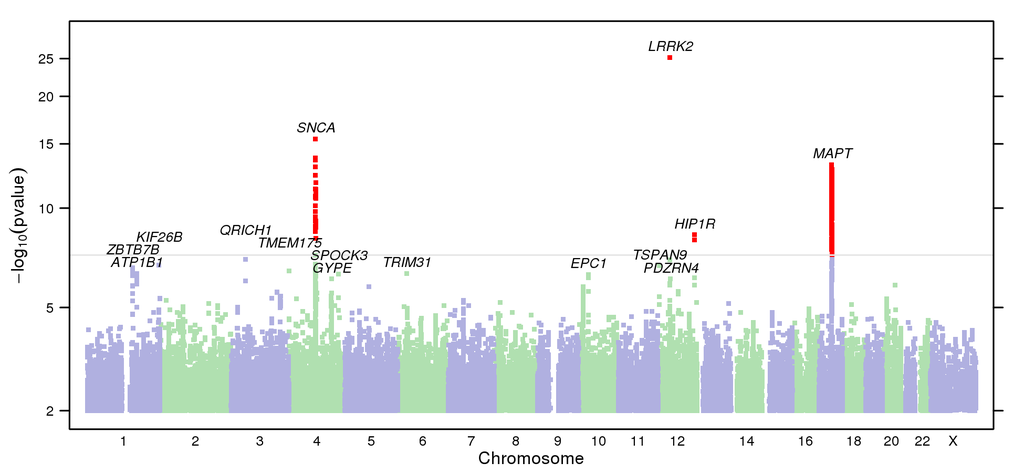

## Q-Q Plot of GWAS Results

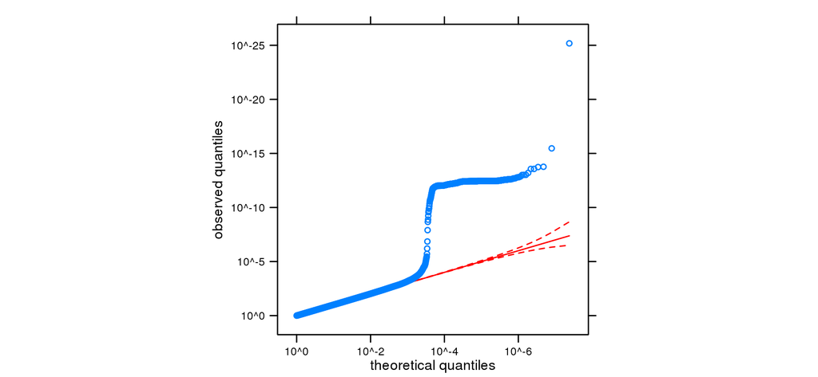

## Index SNPs for Strongest Associations

| cytoband | assay.name | scaffold | position | alleles | src | pvalue | OR | 95% CI | gene.context |
| --- | --- | --- | --- | --- | --- | --- | --- | --- | --- |
| 12q12 | rs34637584 | chr12 | 40734202 | A/G | G | 6.6×10<sup>−26</sup> | 0.084 | [0.059,0.120] | [LRRK2] |
| 4q22.1 | rs356182 | chr4 | 90626111 | A/G | I | 3.4×10<sup>−16</sup> | 1.288 | [1.213,1.369] | GPRIN3---[]--SNCA |
| 17q21.31 | rs200326647 | chr17 | 43995140 | D/I | I | 6.3×10<sup>−14</sup> | 1.331 | [1.232,1.437] | [MAPT] |
| 12q24.31 | rs10847839 | chr12 | 123322560 | C/T | I | 4.2×10<sup>−9</sup> | 0.837 | [0.788,0.887] | [HIP1R] |
| 3p21.31 | rs57230454 | chr3 | 49106542 | D/I | I | 8.4×10<sup>−8</sup> | 1.253 | [1.156,1.358] | [QRICH1] |
| 1q44 | rs56197340 | chr1 | 245364772 | C/T | I | 1.6×10<sup>−7</sup> | 0.794 | [0.726,0.867] | [KIF26B] |
| 12p13.32 | rs73038484 | chr12 | 3436693 | A/G | I | 1.6×10<sup>−7</sup> | 1.243 | [1.148,1.347] | TSPAN9--[]---PRMT8 |
| 1q21.3 | rs71628639 | chr1 | 154988255 | A/C | I | 2.0×10<sup>−7</sup> | 0.537 | [0.433,0.665] | [ZBTB7B] |
| 4p16.3 | rs34311866 | chr4 | 951947 | C/T | I | 3.0×10<sup>−7</sup> | 0.826 | [0.768,0.887] | [TMEM175] |
| 1q24.2 | rs141704337 | chr1 | 169015088 | A/G | I | 3.8×10<sup>−7</sup> | 0.506 | [0.397,0.644] | DPT---[]--ATP1B1 |
| 6p22.1 | rs2023472 | chr6 | 30075864 | A/G | I | 3.8×10<sup>−7</sup> | 0.860 | [0.811,0.911] | [TRIM31] |
| 4q32.3 | rs77597318 | chr4 | 168560439 | C/T | I | 4.0×10<sup>−7</sup> | 1.298 | [1.176,1.434] | SPOCK3---[]---ANXA10 |
| 10p11.22 | rs139249720 | chr10 | 32630747 | A/T | I | 4.2×10<sup>−7</sup> | 1.825 | [1.474,2.261] | [EPC1] |
| 4q31.21 | rs181941027 | chr4 | 144712592 | C/T | I | 6.6×10<sup>−7</sup> | 0.124 | [0.039,0.395] | FREM3--[]--GYPE |
| 12q12 | rs187043470 | chr12 | 41870804 | A/C | I | 6.7×10<sup>−7</sup> | 3.171 | [2.133,4.714] | [PDZRN4] |

## Quality Statistics for Index SNPs

| assay.name | is.v2 | is.v3 | is.v4 | gt.rate | hw.p.value | p.date | freq.b | avg.rsqr | min.rsqr | p.batch | dose.b | qc.mask |
| --- | --- | --- | --- | --- | --- | --- | --- | --- | --- | --- | --- | --- |
| rs34637584 | TRUE | TRUE | TRUE | 1.0000 | 0.0014 | 0.00051 | 0.9991 |  |  |  |  |  |
| rs356182 | FALSE | FALSE | FALSE |  |  |  |  | 0.9265 | 0.9136 | 0.043 | 0.3497 | v2v3v4 |
| rs200326647 | FALSE | FALSE | FALSE |  |  |  |  | 0.9717 | 0.9680 | 0.00068 | 0.7865 | v2v3v4 |
| rs10847839 | FALSE | FALSE | FALSE |  |  |  |  | 0.9405 | 0.8330 | 1.5×10<sup>−24</sup> | 0.6485 | v2v3v4 |
| rs57230454 | FALSE | FALSE | FALSE |  |  |  |  | 0.7930 | 0.7528 | 0.0086 | 0.1654 | v2v3v4 |
| rs56197340 | FALSE | FALSE | FALSE |  |  |  |  | 0.9390 | 0.9153 | 0.65 | 0.1547 | v2v3v4 |
| rs73038484 | FALSE | FALSE | FALSE |  |  |  |  | 0.9050 | 0.8653 | 0.64 | 0.1416 | v2v3v4 |
| rs71628639 | FALSE | FALSE | FALSE |  |  |  |  | 0.9698 | 0.9392 | 0.075 | 0.9895 | v2v3v4 |
| rs34311866 | FALSE | FALSE | TRUE | 1.0000 | 0.0 | 0.0 | 0.7300 | 0.9587 | 0.9474 | 1.1×10<sup>−5</sup> | 0.8164 | v2v3v4 |
| rs141704337 | FALSE | FALSE | FALSE |  |  |  |  | 0.6811 | 0.6129 | 0.0022 | 0.9873 | v2v3v4 |
| rs2023472 | TRUE | TRUE | TRUE | 0.9995 | 0.62 | 0.00085 | 0.6121 | 0.9989 | 0.9976 | 0.30 | 0.6134 | v2v3v4 |
| rs77597318 | FALSE | FALSE | FALSE |  |  |  |  | 0.5355 | 0.4924 | 0.17 | 0.1608 | v2v3v4 |
| rs139249720 | FALSE | FALSE | FALSE |  |  |  |  | 0.8439 | 0.7785 | 0.17 | 0.0118 | v2v3v4 |
| rs181941027 | FALSE | FALSE | FALSE |  |  |  |  | 0.8176 | 0.7011 | 9.5×10<sup>−5</sup> | 0.0044 | v2v3v4 |
| rs187043470 | FALSE | FALSE | FALSE |  |  |  |  | 0.6296 | 0.5414 | 3.3×10<sup>−36</sup> | 0.0038 | v2v3v4 |

## SNP Statistics in the GWAS Sample

| assay.name | AA.0 | AB.0 | BB.0 | im.num.0 | dose.b.0 | AA.1 | AB.1 | BB.1 | im.num.1 | dose.b.1 |
| --- | --- | --- | --- | --- | --- | --- | --- | --- | --- | --- |
| rs34637584 | 1 | 722 | 570687 |  |  | 0 | 39 | 2409 |  |  |
| rs356182 |  |  |  | 571298 | 0.3476 |  |  |  | 2448 | 0.4024 |
| rs200326647 |  |  |  | 571298 | 0.7839 |  |  |  | 2448 | 0.8275 |
| rs10847839 |  |  |  | 571298 | 0.6508 |  |  |  | 2448 | 0.6098 |
| rs57230454 |  |  |  | 571298 | 0.1638 |  |  |  | 2448 | 0.1890 |
| rs56197340 |  |  |  | 571298 | 0.1541 |  |  |  | 2448 | 0.1280 |
| rs73038484 |  |  |  | 571298 | 0.1422 |  |  |  | 2448 | 0.1695 |
| rs71628639 |  |  |  | 571298 | 0.9897 |  |  |  | 2448 | 0.9813 |
| rs34311866 | 54664 | 178001 | 338731 | 571298 | 0.8196 | 221 | 848 | 1379 | 2448 | 0.7907 |
| rs141704337 |  |  |  | 571298 | 0.9877 |  |  |  | 2448 | 0.9804 |
| rs2023472 | 86140 | 271827 | 213110 | 571298 | 0.6115 | 427 | 1222 | 799 | 2448 | 0.5763 |
| rs77597318 |  |  |  | 571298 | 0.1609 |  |  |  | 2448 | 0.1816 |
| rs139249720 |  |  |  | 571298 | 0.0119 |  |  |  | 2448 | 0.0203 |
| rs181941027 |  |  |  | 571298 | 0.0038 |  |  |  | 2448 | 0.0009 |
| rs187043470 |  |  |  | 571298 | 0.0032 |  |  |  | 2448 | 0.0074 |

## Top HLA Allelic Associations

*There were no HLA allelic associations with P<1e-6*

## Top HLA Amino Acid Associations

*There were no HLA amino acid associations with P<1e-6*

## Annotation Summary

| assay.name | Ngt | Nim | nhgri | coding | eqtl | clinical | dnase | gene.context |
| --- | --- | --- | --- | --- | --- | --- | --- | --- |
| rs34637584 | 1 | 0 | Y | Y | . | Y | . | [LRRK2] |
| rs356182 | 19 | 74 | Y | . | . | . | . | GPRIN3---[]--SNCA |
| rs200326647 | 97 | 3256 | Y | Y | Y | Y | Y | [MAPT] |
| rs10847839 | 1 | 1 | Y | . | . | . | Y | [HIP1R] |
| rs57230454 | 0 | 3 | . | . | . | . | . | [QRICH1] |
| rs56197340 | 0 | 1 | . | . | . | . | Y | [KIF26B] |
| rs73038484 | 0 | 1 | . | . | . | . | Y | TSPAN9--[]---PRMT8 |
| rs71628639 | 2 | 6 | Y | Y | Y | Y | Y | [ZBTB7B] |
| rs34311866 | 1 | 0 | Y | Y | . | . | Y | [TMEM175] |
| rs141704337 | 0 | 6 | . | . | . | . | . | DPT---[]--ATP1B1 |
| rs2023472 | 1 | 0 | Y | . | Y | . | . | [TRIM31] |
| rs77597318 | 0 | 1 | . | . | . | . | . | SPOCK3---[]---ANXA10 |
| rs139249720 | 0 | 2 | . | . | . | . | Y | [EPC1] |
| rs181941027 | 0 | 1 | . | . | . | . | . | FREM3--[]--GYPE |
| rs187043470 | 0 | 1 | . | . | . | . | . | [PDZRN4] |

## Annotations from NHGRI GWAS Catalog

The following table shows, for each index SNP, all entries in the NHGRI GWAS Catalog that are within 500kb and in at least moderate linkage disequilibrium (r<sup>2</sup> > 0.5).

| region | position | our.name | our.pval | dist | rsqr | assay.name | pvalue | pubmed.id | trait | genes |
| --- | --- | --- | --- | --- | --- | --- | --- | --- | --- | --- |
| 12q12 | 40734202 | rs34637584 | 6.6×10<sup>−26</sup> | 0 | 1.000 | rs34637584 | 2.0×10<sup>−28</sup> | 21738487 | Parkinson’s disease | LRRK2 |
| 4q22.1 | 90626111 | rs356182 | 3.4×10<sup>−16</sup> | 0 | 1.000 | rs356182 | 1.0×10<sup>−56</sup> | 27182965 | Parkinson’s disease | GPRIN3, SNCA |
| 4q22.1 | 90626111 | rs356182 | 3.4×10<sup>−16</sup> | 0 | 1.000 | rs356182 | 4.0×10<sup>−73</sup> | 25064009 | Parkinson’s disease | SNCA |
| 4q22.1 | 90626111 | rs356182 | 3.4×10<sup>−16</sup> | 11490 | 0.758 | rs356219 | 6.0×10<sup>−65</sup> | 22438815 | Parkinson’s disease | SNCA |
| 4q22.1 | 90626111 | rs356182 | 3.4×10<sup>−16</sup> | 11490 | 0.758 | rs356219 | 2.0×10<sup>−47</sup> | 21292315 | Parkinson’s disease | SNCA |
| 4q22.1 | 90626111 | rs356182 | 3.4×10<sup>−16</sup> | 15229 | 0.520 | rs356220 | 3.0×10<sup>−11</sup> | 20711177 | Parkinson’s disease | SNCA |
| 4q22.1 | 90626111 | rs356182 | 3.4×10<sup>−16</sup> | 15229 | 0.520 | rs356220 | 9.0×10<sup>−16</sup> | 21044948 | Parkinson’s disease | SNCA |
| 4q22.1 | 90626111 | rs356182 | 3.4×10<sup>−16</sup> | 15229 | 0.520 | rs356220 | 3.0×10<sup>−8</sup> | 21084426 | Parkinson’s disease | SNCA |
| 4q22.1 | 90626111 | rs356182 | 3.4×10<sup>−16</sup> | 15229 | 0.520 | rs356220 | 3.0×10<sup>−11</sup> | 24511991 | Parkinson’s disease | SNCA |
| 4q22.1 | 90626111 | rs356182 | 3.4×10<sup>−16</sup> | 15229 | 0.520 | rs356220 | 2.0×10<sup>−19</sup> | 21738487 | Parkinson’s disease | SNCA |
| 4q22.1 | 90626111 | rs356182 | 3.4×10<sup>−16</sup> | 15229 | 0.520 | rs356220 | 8.0×10<sup>−35</sup> | 22451204 | Parkinson’s disease | SNCA |
| 17q21.31 | 43995140 | rs200326647 | 6.3×10<sup>−14</sup> | −481699 | 0.685 | rs11012 | 6.0×10<sup>−8</sup> | 20070850 | Parkinson’s disease | MAPT, PLEKHM1, IMP5 |
| 17q21.31 | 43995140 | rs200326647 | 6.3×10<sup>−14</sup> | −478738 | 0.685 | rs17631303 | 1.0×10<sup>−8</sup> | 23544013 | Ovarian cancer in BRCA1 mutation carriers | intergenic |
| 17q21.31 | 43995140 | rs200326647 | 6.3×10<sup>−14</sup> | −289539 | 0.971 | rs365825 | 4.0×10<sup>−32</sup> | 27182965 | Parkinson’s disease | CRHR1, LRRC37A3 |
| 17q21.31 | 43995140 | rs200326647 | 6.3×10<sup>−14</sup> | −280290 | 0.978 | rs2942168 | 1.0×10<sup>−28</sup> | 21292315 | Parkinson’s disease | MAPT |
| 17q21.31 | 43995140 | rs200326647 | 6.3×10<sup>−14</sup> | −275997 | 0.971 | rs393152 | 2.0×10<sup>−16</sup> | 19915575 | Parkinson’s disease | MAPT, C17orf69, … |
| 17q21.31 | 43995140 | rs200326647 | 6.3×10<sup>−14</sup> | −275997 | 0.971 | rs393152 | 1.0×10<sup>−12</sup> | 26077951 | Corticobasal degeneration | MAPT |
| 17q21.31 | 43995140 | rs200326647 | 6.3×10<sup>−14</sup> | −170780 | 0.545 | rs7207400 | 5.0×10<sup>−6</sup> | 25778476 | Alzheimer’s disease in APOE e4- carriers | CRHR1 |
| 17q21.31 | 43995140 | rs200326647 | 6.3×10<sup>−14</sup> | −168503 | 0.978 | rs12150672 | 4.0×10<sup>−9</sup> | 28017375 | Red blood cell count |  |
| 17q21.31 | 43995140 | rs200326647 | 6.3×10<sup>−14</sup> | −144208 | 0.911 | rs113518470 | 6.0×10<sup>−11</sup> | 27182965 | Joint mobility (Beighton score) | LRRC37A3, CRHR1 |
| 17q21.31 | 43995140 | rs200326647 | 6.3×10<sup>−14</sup> | −137151 | 0.748 | rs111433752 | 9.0×10<sup>−12</sup> | 27067015 | Neuroticism | Intergenic |
| 17q21.31 | 43995140 | rs200326647 | 6.3×10<sup>−14</sup> | −88312 | 0.970 | rs17689882 | 8.0×10<sup>−9</sup> | 25607358 | Subcortical brain region volumes | CRHR1 |
| 17q21.31 | 43995140 | rs200326647 | 6.3×10<sup>−14</sup> | −71457 | 0.978 | rs12185268 | 3.0×10<sup>−14</sup> | 21738487 | Parkinson’s disease | MAPT |
| 17q21.31 | 43995140 | rs200326647 | 6.3×10<sup>−14</sup> | −70921 | 0.970 | rs12373124 | 5.0×10<sup>−10</sup> | 22693459 | Male-pattern baldness | intergenic |
| 17q21.31 | 43995140 | rs200326647 | 6.3×10<sup>−14</sup> | −69843 | 0.792 | rs17690703 | 6.0×10<sup>−9</sup> | 24429156 | Idiopathic pulmonary fibrosis | SPPL2C, KANSL1, … |
| 17q21.31 | 43995140 | rs200326647 | 6.3×10<sup>−14</sup> | −17313 | 0.978 | rs1864325 | 5.0×10<sup>−11</sup> | 22504420 | Bone mineral density | MAPT |
| 17q21.31 | 43995140 | rs200326647 | 6.3×10<sup>−14</sup> | −492 | 0.971 | rs17649553 | 2.0×10<sup>−48</sup> | 25064009 | Parkinson’s disease | MAPT |
| 17q21.31 | 43995140 | rs200326647 | 6.3×10<sup>−14</sup> | 61627 | 0.978 | rs1981997 | 9.0×10<sup>−14</sup> | 23583980 | Interstitial lung disease | MAPT |
| 17q21.31 | 43995140 | rs200326647 | 6.3×10<sup>−14</sup> | 85924 | 0.970 | rs8070723 | 7.0×10<sup>−12</sup> | 21044948 | Parkinson’s disease | MAPT |
| 17q21.31 | 43995140 | rs200326647 | 6.3×10<sup>−14</sup> | 85924 | 0.970 | rs8070723 | 2.0×10<sup>−118</sup> | 21685912 | Progressive supranuclear palsy | MAPT |
| 17q21.31 | 43995140 | rs200326647 | 6.3×10<sup>−14</sup> | 170940 | 0.689 | rs201408539 | 8.0×10<sup>−20</sup> | 27182965 | Male-pattern baldness | KANSL1 |
| 17q21.31 | 43995140 | rs200326647 | 6.3×10<sup>−14</sup> | 192117 | 0.949 | rs9303525 | 8.0×10<sup>−15</sup> | 22504418 | Intracranial volume | MAPT, GRN, … |
| 17q21.31 | 43995140 | rs200326647 | 6.3×10<sup>−14</sup> | 192352 | 0.978 | rs17577094 | 8.0×10<sup>−9</sup> | 24842889 | Parkinson’s disease | MAPT |
| 17q21.31 | 43995140 | rs200326647 | 6.3×10<sup>−14</sup> | 197450 | 0.716 | rs35524223 | 1.0×10<sup>−13</sup> | 28166213 | Lung function (FEV1) | KANSL1 |
| 17q21.31 | 43995140 | rs200326647 | 6.3×10<sup>−14</sup> | 197450 | 0.716 | rs35524223 | 7.0×10<sup>−13</sup> | 28166213 | Lung function (FVC) | KANSL1 |
| 12q24.31 | 123322560 | rs10847839 | 4.2×10<sup>−9</sup> | −26266 | 0.566 | rs12817488 | 3.0×10<sup>−13</sup> | 21292315 | Parkinson’s disease | CCDC62, HIP1R |
| 1q21.3 | 154988255 | rs71628639 | 2.0×10<sup>−7</sup> | 119912 | 0.889 | rs12726330 | 5.0×10<sup>−8</sup> | 22451204 | Parkinson’s disease | GBA |
| 1q21.3 | 154988255 | rs71628639 | 2.0×10<sup>−7</sup> | 146781 | 0.889 | rs35749011 | 1.0×10<sup>−29</sup> | 25064009 | Parkinson’s disease | GBA, SYT11 |
| 1q21.3 | 154988255 | rs71628639 | 2.0×10<sup>−7</sup> | 217912 | 0.785 | rs2230288 | 5.0×10<sup>−17</sup> | 27182965 | Parkinson’s disease | GBA |
| 4p16.3 | 951947 | rs34311866 | 3.0×10<sup>−7</sup> | 0 | 1.000 | rs34311866 | 1.0×10<sup>−43</sup> | 25064009 | Parkinson’s disease | TMEM175, GAK, DGKQ |
| 4p16.3 | 951947 | rs34311866 | 3.0×10<sup>−7</sup> | 12412 | 0.585 | rs11248060 | 3.0×10<sup>−12</sup> | 22438815 | Parkinson’s disease | GAK, DGKQ |
| 4p16.3 | 951947 | rs34311866 | 3.0×10<sup>−7</sup> | 12412 | 0.585 | rs11248060 | 3.0×10<sup>−9</sup> | 22451204 | Parkinson’s disease | DGKQ |
| 4p16.3 | 951947 | rs34311866 | 3.0×10<sup>−7</sup> | 12412 | 0.585 | rs11248060 | 2.0×10<sup>−6</sup> | 20070850 | Parkinson’s disease | DGKQ |
| 6p22.1 | 30075864 | rs2023472 | 3.8×10<sup>−7</sup> | 0 | 1.000 | rs2023472 | 3.0×10<sup>−15</sup> | 23417110 | Beta-2 microglubulin plasma levels | TRIM31 |

## Replication of GWAS Catalog Results

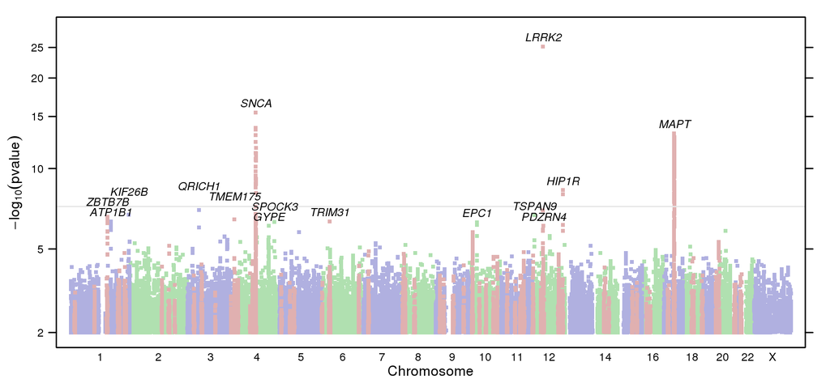

The following table shows, for each GWAS Catalog result for similar traits, our association test result for our best available proxy (distance < 100kb, r<sup>2</sup> > 0.8).

| region | position | our.name | our.pval | dist | rsqr | assay.name | pvalue | pubmed.id | trait | genes |
| --- | --- | --- | --- | --- | --- | --- | --- | --- | --- | --- |
| 4p16.3 | 852313 | rs1564282 | 0.011 | 0 | 1.000 | rs1564282 | 7.0×10<sup>−7</sup> | 18985386 | Parkinson’s disease (familial) | GAK, DGKQ |
| 1p36.13 | 19139517 | rs12063142 | 0.046 | 0 | 1.000 | rs12063142 | 5.0×10<sup>−7</sup> | 20070850 | Parkinson’s disease | TAS1R2 |
| 1p21.1 | 101880005 | rs2338971 | 0.44 | 0 | 1.000 | rs2338971 | 4.0×10<sup>−10</sup> | 24511991 | Parkinson’s disease | HUSEYO |
| 1q21.3 | 154855055 | rs1630500 | 0.51 | 0 | 1.000 | rs1630500 | 2.0×10<sup>−8</sup> | 24842889 | Parkinson’s disease | GBA |
| 1q22 | 155108167 | rs12726330 | 3.7×10<sup>−7</sup> | 0 | 1.000 | rs12726330 | 5.0×10<sup>−8</sup> | 22451204 | Parkinson’s disease | GBA |
| 1q22 | 155135036 | rs35749011 | 4.7×10<sup>−7</sup> | 0 | 1.000 | rs35749011 | 1.0×10<sup>−29</sup> | 25064009 | Parkinson’s disease | GBA, SYT11 |
| 1q22 | 155206167 | rs2230288 | 4.5×10<sup>−7</sup> | 0 | 1.000 | rs2230288 | 5.0×10<sup>−17</sup> | 27182965 | Parkinson’s disease | GBA |
| 1q22 | 156030037 | rs34372695 | 0.00043 | 0 | 1.000 | rs34372695 | 4.0×10<sup>−12</sup> | 21292315 | Parkinson’s disease | SYT11 |
| 1q32.1 | 205713378 | rs823128 | 0.16 | 0 | 1.000 | rs823128 | 7.0×10<sup>−8</sup> | 19915575 | Parkinson’s disease | PARK16, NUCKS1 |
| 1q32.1 | 205719532 | rs823114 | 0.0063 | 0 | 1.000 | rs823114 | 3.0×10<sup>−6</sup> | 24842889 | Parkinson’s disease | PARK16 |
| 1q32.1 | 205723572 | rs823118 | 0.0060 | 0 | 1.000 | rs823118 | 6.0×10<sup>−12</sup> | 27182965 | Parkinson’s disease | RAB7L1, NUCKS1 |
| 1q32.1 | 205723572 | rs823118 | 0.0060 | 0 | 1.000 | rs823118 | 2.0×10<sup>−16</sup> | 25064009 | Parkinson’s disease | NUCKS1, RAB7L1 |
| 1q32.1 | 205752665 | rs947211 | 0.023 | 0 | 1.000 | rs947211 | 2.0×10<sup>−12</sup> | 19915576 | Parkinson’s disease | SLC45A3, PARK16, … |
| 1q32.1 | 205764640 | rs823156 | 0.065 | 0 | 1.000 | rs823156 | 1.0×10<sup>−7</sup> | 21738487 | Parkinson’s disease | SLC41A1 |
| 1q42.13 | 228153917 | rs849898 | 0.62 | 0 | 1.000 | rs849898 | 1.0×10<sup>−6</sup> | 26227905 | Parkinson’s disease | WNT9A, LOC728728 |
| 1q42.2 | 232664611 | rs10797576 | 0.0017 | 0 | 1.000 | rs10797576 | 5.0×10<sup>−10</sup> | 25064009 | Parkinson’s disease | SIPA1L2 |
| 2q21.3 | 135539967 | rs6430538 | 0.00099 | 0 | 1.000 | rs6430538 | 9.0×10<sup>−20</sup> | 25064009 | Parkinson’s disease | ACMSD, TMEM163 |
| 2q21.3 | 135539967 | rs6430538 | 0.00099 | 0 | 1.000 | rs6430538 | 2.0×10<sup>−7</sup> | 22451204 | Parkinson’s disease | intergenic |
| 2q31.1 | 169110394 | rs1474055 | 0.0017 | 0 | 1.000 | rs1474055 | 1.0×10<sup>−20</sup> | 25064009 | Parkinson’s disease | STK39 |
| 2q31.1 | 169117025 | rs2102808 | 0.0016 | 0 | 1.000 | rs2102808 | 4.0×10<sup>−10</sup> | 21292315 | Parkinson’s disease | STK39 |
| 2q31.1 | 169143035 | rs9917256 | 0.0045 | 0 | 1.000 | rs9917256 | 3.0×10<sup>−6</sup> | 22451204 | Parkinson’s disease | intergenic |
| 2q31.1 | 169155595 | rs13016703 | 0.0049 | 0 | 1.000 | rs13016703 | 3.0×10<sup>−16</sup> | 27182965 | Parkinson’s disease | STK39, CERS6 |
| 2q32.2 | 189897394 | rs11186 | 0.50 | 0 | 1.000 | rs11186 | 1.0×10<sup>−6</sup> | 26227905 | Parkinson’s disease | COL5A2 |
| 3p24.1 | 28705764 | rs7617877 | 0.16 | 0 | 1.000 | rs7617877 | 3.0×10<sup>−6</sup> | 21044948 | Parkinson’s disease |  |
| 3p14.2 | 59427797 | rs6783485 | 0.89 | 0 | 1.000 | rs6783485 | 1.0×10<sup>−6</sup> | 26227905 | Parkinson’s disease | C3orf67, LOC339902 |
| 3q13.32 | 118615463 | rs1879553 | 0.50 | 0 | 1.000 | rs1879553 | 1.0×10<sup>−6</sup> | 26227905 | Parkinson’s disease | LOC285194, IGSF11 |
| 3q26.33 | 182730291 | rs9858038 | 0.17 | 0 | 1.000 | rs9858038 | 3.0×10<sup>−14</sup> | 27182965 | Parkinson’s disease | DCUN1D1, MCCC1 |
| 3q26.33 | 182755209 | rs2270968 | 0.15 | 0 | 1.000 | rs2270968 | 3.0×10<sup>−8</sup> | 28011712 | Parkinson’s disease | MCCC1, DCUN1D1, LAMP3 |
| 3q26.33 | 182760073 | rs10513789 | 0.19 | 0 | 1.000 | rs10513789 | 3.0×10<sup>−10</sup> | 21738487 | Parkinson’s disease | MCCC1, LAMP3 |
| 3q26.33 | 182762437 | rs12637471 | 0.20 | 0 | 1.000 | rs12637471 | 2.0×10<sup>−21</sup> | 25064009 | Parkinson’s disease | MCCC1 |

[output cut: 121 more lines]

## Nearby Coding SNPs

| region | position | our.name | our.pval | dist | rsqr | assay.name | gene | alleles | b.allele.residue | hgvs | consequence |
| --- | --- | --- | --- | --- | --- | --- | --- | --- | --- | --- | --- |
| 12q12 | 40734202 | rs34637584 | 6.6×10<sup>−26</sup> | 0 | 1.000 | rs34637584 | LRRK2 | A/G | Gly | ENSP00000298910.7:p.Gly2019Ser | missense_variant |
| 17q21.31 | 43995140 | rs200326647 | 6.3×10<sup>−14</sup> | −487843 | 0.576 | rs12949256 | ARHGAP27 | C/T | Thr | ENSP00000403323.1:p.Ala117Thr | missense_variant |
| 17q21.31 | 43995140 | rs200326647 | 6.3×10<sup>−14</sup> | −72198 | 0.978 | rs62621252 | SPPL2C | C/T | Ser | ENSP00000332488.5:p.Ser224Pro | missense_variant |
| 17q21.31 | 43995140 | rs200326647 | 6.3×10<sup>−14</sup> | −71874 | 0.978 | rs62054815 | SPPL2C | A/G | Ala | ENSP00000332488.5:p.Ala332Thr | missense_variant |
| 17q21.31 | 43995140 | rs200326647 | 6.3×10<sup>−14</sup> | −71486 | 0.978 | rs12185233 | SPPL2C | A/G | Arg | ENSP00000332488.5:p.Arg461His, ENSP00000332488.5:p.Arg461Pro | missense_variant, missense_variant |
| 17q21.31 | 43995140 | rs200326647 | 6.3×10<sup>−14</sup> | −71457 | 0.978 | rs12185268 | SPPL2C | A/G | Val | ENSP00000332488.5:p.Ile471Val | missense_variant |
| 17q21.31 | 43995140 | rs200326647 | 6.3×10<sup>−14</sup> | −71067 | 0.978 | rs12373123 | SPPL2C | C/T | Ser | ENSP00000332488.5:p.Ser601Pro | missense_variant |
| 17q21.31 | 43995140 | rs200326647 | 6.3×10<sup>−14</sup> | −71010 | 0.978 | rs12373139 | SPPL2C | A/G | Gly | ENSP00000332488.5:p.Gly620Arg | missense_variant |
| 17q21.31 | 43995140 | rs200326647 | 6.3×10<sup>−14</sup> | −70940 | 0.970 | rs12373142 | SPPL2C | C/G | Arg | ENSP00000332488.5:p.Pro643Arg | missense_variant |
| 17q21.31 | 43995140 | rs200326647 | 6.3×10<sup>−14</sup> | 65635 | 0.978 | rs63750417 | MAPT | A/C | Pro | ENSP00000340820.5:p.Pro202Gln, ENSP00000340820.5:p.Pro202Leu | missense_variant, missense_variant |
| 17q21.31 | 43995140 | rs200326647 | 6.3×10<sup>−14</sup> | 65883 | 0.978 | rs62063786 | MAPT | A/G | Asp | ENSP00000340820.5:p.Asp285Asn | missense_variant |
| 17q21.31 | 43995140 | rs200326647 | 6.3×10<sup>−14</sup> | 65896 | 0.978 | rs62063787 | MAPT | C/T | Val | ENSP00000340820.5:p.Val289Ala | missense_variant |
| 17q21.31 | 43995140 | rs200326647 | 6.3×10<sup>−14</sup> | 66138 | 0.978 | rs17651549 | MAPT | C/T | Trp | ENSP00000340820.5:p.Arg370Trp | missense_variant |
| 17q21.31 | 43995140 | rs200326647 | 6.3×10<sup>−14</sup> | 72260 | 0.978 | rs10445337 | MAPT | C/T | Ser | ENSP00000340820.5:p.Ser447Pro | missense_variant |
| 17q21.31 | 43995140 | rs200326647 | 6.3×10<sup>−14</sup> | 81525 | 0.978 | rs62063857 | STH | A/G | Arg | ENSP00000443168.1:p.Gln7Arg | missense_variant |
| 17q21.31 | 43995140 | rs200326647 | 6.3×10<sup>−14</sup> | 113766 | 0.978 | rs34579536 | KANSL1 | A/G | Thr | ENSP00000262419.6:p.Ile1085Thr | missense_variant |
| 17q21.31 | 43995140 | rs200326647 | 6.3×10<sup>−14</sup> | 115401 | 0.978 | rs35833914 | KANSL1 | A/G | Asp | ENST00000262419.10:c.2742C>T(p.=), ENSP00000262419.6:p.Asp914Glu | synonymous_variant, missense_variant |
| 17q21.31 | 43995140 | rs200326647 | 6.3×10<sup>−14</sup> | 121979 | 0.978 | rs34043286 | KANSL1 | A/G | Pro | ENSP00000262419.6:p.Ser718Pro | missense_variant |
| 17q21.31 | 43995140 | rs200326647 | 6.3×10<sup>−14</sup> | 253697 | 0.768 | rs35643216 | KANSL1 | C/T | Asn | ENSP00000262419.6:p.Asn225Asp | missense_variant |
| 17q21.31 | 43995140 | rs200326647 | 6.3×10<sup>−14</sup> | 254059 | 0.768 | rs17585974 | KANSL1 | G/T | Lys | ENSP00000262419.6:p.Lys104Thr | missense_variant |
| 1q21.3 | 154988255 | rs71628639 | 2.0×10<sup>−7</sup> | 187936 | 0.889 | rs35682329 | THBS3 | A/G | Ala | ENSP00000357362.3:p.Val29Ala | missense_variant |
| 1q21.3 | 154988255 | rs71628639 | 2.0×10<sup>−7</sup> | 217912 | 0.785 | rs2230288 | GBA | C/T | Lys | ENSP00000314508.5:p.Glu365Lys | missense_variant |
| 1q21.3 | 154988255 | rs71628639 | 2.0×10<sup>−7</sup> | 461014 | 0.637 | rs12734374 | ASH1L | A/T | Asn | ENSP00000376204.3:p.Ile1131Asn | missense_variant |
| 4p16.3 | 951947 | rs34311866 | 3.0×10<sup>−7</sup> | 0 | 1.000 | rs34311866 | TMEM175 | C/T | Met | ENSP00000264771.4:p.Met393Thr | missense_variant |
| 4p16.3 | 951947 | rs34311866 | 3.0×10<sup>−7</sup> | 2916 | 0.564 | rs10516158 | DGKQ | C/T | Met | ENSP00000273814.3:p.Val901Met | missense_variant |
| 4p16.3 | 951947 | rs34311866 | 3.0×10<sup>−7</sup> | 3310 | 0.571 | rs11730111 | DGKQ | C/T | Met | ENSP00000273814.3:p.Val858Met | missense_variant&splice_region_variant |
| 4p16.3 | 951947 | rs34311866 | 3.0×10<sup>−7</sup> | 12886 | 0.595 | rs748483 | DGKQ | A/G | Ser | ENSP00000273814.3:p.Phe100Ser | missense_variant |

## Nearby Expression QTLs

| region | position | our.name | our.pval | dist | rsqr | assay.name | eqtl.dist | eqtl.gene | eqtl.pval | eqtl.rsqr | tissue | pubmed.id | match |
| --- | --- | --- | --- | --- | --- | --- | --- | --- | --- | --- | --- | --- | --- |
| 17q21.31 | 43995140 | rs200326647 | 6.3×10<sup>−14</sup> | −487737 | 0.685 | rs116926649 | 862696 | LRRC37A | 1.0×10<sup>−8</sup> | 0.274 | Muscle_Skeletal | 23715323 | FALSE |
| 17q21.31 | 43995140 | rs200326647 | 6.3×10<sup>−14</sup> | −481699 | 0.685 | rs11012 | 201708 | MGC57346 | 6.7×10<sup>−23</sup> | 0.297 | B-Cell | 22446964 |  |
| 17q21.31 | 43995140 | rs200326647 | 6.3×10<sup>−14</sup> | −445614 | 0.700 | rs17631676 | 42490 | LRRC37A4 | 6.0×10<sup>−208</sup> | 0.475 | Monocyte | 20502693 |  |
| 17q21.31 | 43995140 | rs200326647 | 6.3×10<sup>−14</sup> | −445614 | 0.700 | rs17631676 | 170002 | C17ORF69 | 7.7×10<sup>−5</sup> | 0.055 | B-Cell | 22446964 |  |
| 17q21.31 | 43995140 | rs200326647 | 6.3×10<sup>−14</sup> | −445614 | 0.700 | rs17631676 | 165623 | MGC57346 | 1.8×10<sup>−59</sup> | 0.613 | Monocyte | 22446964 |  |
| 17q21.31 | 43995140 | rs200326647 | 6.3×10<sup>−14</sup> | −445614 | 0.700 | rs17631676 | 378322 | HS.554608 | 0.00057 | 0.042 | B-Cell | 22446964 |  |
| 17q21.31 | 43995140 | rs200326647 | 6.3×10<sup>−14</sup> | −438278 | 0.659 | rs147797084 | 11278 | PLEKHM1,PLEKHM1P | 5.6×10<sup>−9</sup> | 0.254 | Brain | 25174004 | TRUE |
| 17q21.31 | 43995140 | rs200326647 | 6.3×10<sup>−14</sup> | −422721 | 0.852 | rs149056764 | 24606 | LRRC37A4,LRRC37A3,LOC652203,LRRC37A2 | 8.3×10<sup>−20</sup> | 0.453 | Brain Cerebellum | 25174004 | FALSE |
| 17q21.31 | 43995140 | rs200326647 | 6.3×10<sup>−14</sup> | −422721 | 0.852 | rs149056764 | 11479 | LRRC37A4 | 1.6×10<sup>−17</sup> | 0.420 | Brain Cerebellum | 25174004 | FALSE |
| 17q21.31 | 43995140 | rs200326647 | 6.3×10<sup>−14</sup> | −422721 | 0.852 | rs149056764 | 11479 | LRRC37A4 | 1.1×10<sup>−10</sup> | 0.294 | Brain Occipital Cortex | 25174004 | FALSE |
| 17q21.31 | 43995140 | rs200326647 | 6.3×10<sup>−14</sup> | −422721 | 0.852 | rs149056764 | 24606 | LRRC37A4,LRRC37A3,LOC652203,LRRC37A2 | 5.5×10<sup>−7</sup> | 0.201 | Brain Putamen | 25174004 | FALSE |
| 17q21.31 | 43995140 | rs200326647 | 6.3×10<sup>−14</sup> | −422721 | 0.852 | rs149056764 | 24606 | LRRC37A4,LRRC37A3,LOC652203,LRRC37A2 | 2.2×10<sup>−12</sup> | 0.330 | Brain Occipital Cortex | 25174004 | FALSE |
| 17q21.31 | 43995140 | rs200326647 | 6.3×10<sup>−14</sup> | −422721 | 0.852 | rs149056764 | 11479 | LRRC37A4 | 4.4×10<sup>−7</sup> | 0.203 | Brain Substantia Nigra | 25174004 | FALSE |
| 17q21.31 | 43995140 | rs200326647 | 6.3×10<sup>−14</sup> | −422721 | 0.852 | rs149056764 | 24606 | LRRC37A4,LRRC37A3,LOC652203,LRRC37A2 | 9.0×10<sup>−11</sup> | 0.296 | Brain Temporal Cortex | 25174004 | FALSE |
| 17q21.31 | 43995140 | rs200326647 | 6.3×10<sup>−14</sup> | −422721 | 0.852 | rs149056764 | 24606 | LRRC37A4,LRRC37A3,LOC652203,LRRC37A2 | 1.1×10<sup>−6</sup> | 0.192 | Brain Medulla | 25174004 | FALSE |
| 17q21.31 | 43995140 | rs200326647 | 6.3×10<sup>−14</sup> | −422721 | 0.852 | rs149056764 | 11479 | LRRC37A4 | 3.0×10<sup>−11</sup> | 0.306 | Brain Thalamus | 25174004 | FALSE |
| 17q21.31 | 43995140 | rs200326647 | 6.3×10<sup>−14</sup> | −333120 | 0.674 | rs116954807 | 150233 | ARHGAP27 | 6.1×10<sup>−7</sup> | 0.238 | Skin_Sun_Exposed_Lower_leg | 23715323 | FALSE |
| 17q21.31 | 43995140 | rs200326647 | 6.3×10<sup>−14</sup> | −313370 | 0.555 | chr17:43681770:D | 239247 | MAPT-AS1 | 1.0×10<sup>−8</sup> | 0.274 | Muscle_Skeletal | 23715323 |  |
| 17q21.31 | 43995140 | rs200326647 | 6.3×10<sup>−14</sup> | −312817 | 0.689 | rs186806998 | 289507 | MAPT,LOC100130148 | 5.2×10<sup>−6</sup> | 0.172 | Brain | 25174004 | TRUE |
| 17q21.31 | 43995140 | rs200326647 | 6.3×10<sup>−14</sup> | −308720 | 0.940 | rs117287690 | 12847 | CRHR1 | 2.4×10<sup>−19</sup> | 0.792 | Artery_Aorta | 23715323 | FALSE |
| 17q21.31 | 43995140 | rs200326647 | 6.3×10<sup>−14</sup> | −307872 | 0.853 | rs138221403 | 284480 | MAPT | 2.6×10<sup>−6</sup> | 0.348 | Artery_Aorta | 23715323 | TRUE |
| 17q21.31 | 43995140 | rs200326647 | 6.3×10<sup>−14</sup> | −306823 | 0.935 | rs144374863 | 681782 | LRRC37A | 4.0×10<sup>−10</sup> | 0.348 | Skin_Sun_Exposed_Lower_leg | 23715323 | FALSE |
| 17q21.31 | 43995140 | rs200326647 | 6.3×10<sup>−14</sup> | −306561 | 0.808 | rs117656745 | 60878 | LRRC37A4P | 4.3×10<sup>−29</sup> | 0.746 | Skin_Sun_Exposed_Lower_leg | 23715323 | TRUE |
| 17q21.31 | 43995140 | rs200326647 | 6.3×10<sup>−14</sup> | −306235 | 0.895 | rs138311123 | 681194 | LRRC37A | 2.6×10<sup>−29</sup> | 0.289 | Lymphoblastoid | 24037378 |  |
| 17q21.31 | 43995140 | rs200326647 | 6.3×10<sup>−14</sup> | −306235 | 0.895 | rs138311123 | 899972 | LRRC37A2 | 2.2×10<sup>−20</sup> | 0.206 | Lymphoblastoid | 24037378 |  |
| 17q21.31 | 43995140 | rs200326647 | 6.3×10<sup>−14</sup> | −304503 | 0.948 | rs147670174 | 7057 | CRHR1-IT1 | 4.8×10<sup>−28</sup> | 0.699 | Lung | 23715323 | FALSE |
| 17q21.31 | 43995140 | rs200326647 | 6.3×10<sup>−14</sup> | −278985 | 0.676 | rs112550936 | 104079 | RP11-798G7.5 | 4.9×10<sup>−8</sup> | 0.336 | Esophagus_Mucosa | 23715323 | TRUE |
| 17q21.31 | 43995140 | rs200326647 | 6.3×10<sup>−14</sup> | −275997 | 0.971 | rs393152 | 580720 | NMT1 | 0.00045 | 0.156 | Lymphoblastoid | 19644074 |  |
| 17q21.31 | 43995140 | rs200326647 | 6.3×10<sup>−14</sup> | −275311 | 0.896 | rs141586316 | 0 | CRHR1 | 8.1×10<sup>−12</sup> | 0.494 | Esophagus_Muscularis | 23715323 | FALSE |
| 17q21.31 | 43995140 | rs200326647 | 6.3×10<sup>−14</sup> | −250796 | 0.842 | rs1635298 | 158742 | LRRC37A4,AC091132.16-2,AC091132.16-1 | 6.1×10<sup>−10</sup> |  | Whole_Blood | 24013639 | TRUE |

[output cut: 166 more lines]

## Nearby DNase Hotspots

| assay.name | region | position | dist | rsqr | best.tissue | best.score | tissue.count | hotspot.end | our.name | our.position | our.pval |
| --- | --- | --- | --- | --- | --- | --- | --- | --- | --- | --- | --- |
| rs112647192 | 17q21.31 | 43994623 | −517 | 0.978 | epithelial lung carcinoma (A549) | 167 | 1 | 43994675 | rs200326647 | 43995140 | 6.3×10<sup>−14</sup> |
| rs113579895 | 17q21.31 | 43994648 | −492 | 0.971 | epithelial lung carcinoma (A549) | 167 | 1 | 43994675 | rs200326647 | 43995140 | 6.3×10<sup>−14</sup> |
| rs113028763 | 17q21.31 | 43994952 | −188 | 0.963 | fetal lung fibroblast (AG04450) | 171 | 3 | 43995035 | rs200326647 | 43995140 | 6.3×10<sup>−14</sup> |
| rs117537303 | 17q21.31 | 43995990 | 850 | 0.978 | fetal buttock/thigh fibroblast (AG04449) | 161 | 2 | 43996075 | rs200326647 | 43995140 | 6.3×10<sup>−14</sup> |
| rs10847839 | 12q24.31 | 123322560 | 0 | 1.000 | hippocampal astrocytes | 743 | 39 | 123322870 | rs10847839 | 123322560 | 4.2×10<sup>−9</sup> |
| rs56197340 | 1q44 | 245364772 | 0 | 1.000 | epithelial lung carcinoma (A549) | 190 | 1 | 245364775 | rs56197340 | 245364772 | 1.6×10<sup>−7</sup> |
| rs73038484 | 12p13.32 | 3436693 | 0 | 1.000 | adult toe fibroblast (AG09309) | 357 | 4 | 3436755 | rs73038484 | 3436693 | 1.6×10<sup>−7</sup> |
| rs71628639 | 1q21.3 | 154988255 | 0 | 1.000 | B-lymphocyte lymphoblastoid (GM12892) | 904 | 31 | 154989235 | rs71628639 | 154988255 | 2.0×10<sup>−7</sup> |
| rs34311866 | 4p16.3 | 951947 | 0 | 1.000 | neuroblastoma | 360 | 10 | 952135 | rs34311866 | 951947 | 3.0×10<sup>−7</sup> |
| rs139249720 | 10p11.22 | 32630747 | 0 | 1.000 | abdominal skin fibroblasts (AG10803) | 257 | 6 | 32630810 | rs139249720 | 32630747 | 4.2×10<sup>−7</sup> |

## Nearby Clinical Variants

| source | region | our.name | our.pval | dist | rsqr | assay.name | gene | phenotype | accession |
| --- | --- | --- | --- | --- | --- | --- | --- | --- | --- |
| omim | 12q12 | rs34637584 | 6.6×10<sup>−26</sup> | 0 | 1.000 | rs34637584 | LRRK2 |  |  |
| clinvar | 12q12 | rs34637584 | 6.6×10<sup>−26</sup> | 0 | 1.000 | rs34637584 | LRRK2 | Parkinson disease 8, autosomal dominant | NCBI curation: |
| clinvar | 17q21.31 | rs200326647 | 6.3×10<sup>−14</sup> | 65635 | 0.978 | rs63750417 | MAPT | Parkinson-dementia syndrome | NCBI curation: |
| clinvar | 17q21.31 | rs200326647 | 6.3×10<sup>−14</sup> | 65635 | 0.978 | rs63750417 | MAPT | Pick’s disease | Office of Rare Diseases:7392;SNOMED CT:13092008 |
| clinvar | 17q21.31 | rs200326647 | 6.3×10<sup>−14</sup> | 65635 | 0.978 | rs63750417 | MAPT | Frontotemporal dementia | Office of Rare Diseases:8436;SNOMED CT:230270009 |
| clinvar | 17q21.31 | rs200326647 | 6.3×10<sup>−14</sup> | 65635 | 0.978 | rs63750417 | MAPT | Parkinson’s disease | SNOMED CT:49049000 |
| clinvar | 17q21.31 | rs200326647 | 6.3×10<sup>−14</sup> | 65635 | 0.978 | rs63750417 | MAPT | Progressive supranuclear ophthalmoplegia | SNOMED CT:28978003 |
| clinvar | 17q21.31 | rs200326647 | 6.3×10<sup>−14</sup> | 65883 | 0.978 | rs62063786 | MAPT | Progressive supranuclear ophthalmoplegia | SNOMED CT:28978003 |
| clinvar | 17q21.31 | rs200326647 | 6.3×10<sup>−14</sup> | 65883 | 0.978 | rs62063786 | MAPT | Parkinson’s disease | SNOMED CT:49049000 |
| clinvar | 17q21.31 | rs200326647 | 6.3×10<sup>−14</sup> | 65883 | 0.978 | rs62063786 | MAPT | Frontotemporal dementia | Office of Rare Diseases:8436;SNOMED CT:230270009 |
| clinvar | 17q21.31 | rs200326647 | 6.3×10<sup>−14</sup> | 65883 | 0.978 | rs62063786 | MAPT | Pick’s disease | Office of Rare Diseases:7392;SNOMED CT:13092008 |
| clinvar | 17q21.31 | rs200326647 | 6.3×10<sup>−14</sup> | 65883 | 0.978 | rs62063786 | MAPT | Parkinson-dementia syndrome | NCBI curation: |
| clinvar | 17q21.31 | rs200326647 | 6.3×10<sup>−14</sup> | 65896 | 0.978 | rs62063787 | MAPT | Pick’s disease | Office of Rare Diseases:7392;SNOMED CT:13092008 |
| clinvar | 17q21.31 | rs200326647 | 6.3×10<sup>−14</sup> | 65896 | 0.978 | rs62063787 | MAPT | Parkinson’s disease | SNOMED CT:49049000 |
| clinvar | 17q21.31 | rs200326647 | 6.3×10<sup>−14</sup> | 65896 | 0.978 | rs62063787 | MAPT | Parkinson-dementia syndrome | NCBI curation: |
| clinvar | 17q21.31 | rs200326647 | 6.3×10<sup>−14</sup> | 65896 | 0.978 | rs62063787 | MAPT | Progressive supranuclear ophthalmoplegia | SNOMED CT:28978003 |
| clinvar | 17q21.31 | rs200326647 | 6.3×10<sup>−14</sup> | 65896 | 0.978 | rs62063787 | MAPT | Frontotemporal dementia | Office of Rare Diseases:8436;SNOMED CT:230270009 |
| clinvar | 17q21.31 | rs200326647 | 6.3×10<sup>−14</sup> | 72260 | 0.978 | rs10445337 | MAPT | Parkinson-dementia syndrome | NCBI curation: |
| clinvar | 17q21.31 | rs200326647 | 6.3×10<sup>−14</sup> | 72260 | 0.978 | rs10445337 | MAPT | Frontotemporal dementia | Office of Rare Diseases:8436;SNOMED CT:230270009 |
| clinvar | 17q21.31 | rs200326647 | 6.3×10<sup>−14</sup> | 72260 | 0.978 | rs10445337 | MAPT | Parkinson’s disease | SNOMED CT:49049000 |
| clinvar | 17q21.31 | rs200326647 | 6.3×10<sup>−14</sup> | 72260 | 0.978 | rs10445337 | MAPT | Progressive supranuclear ophthalmoplegia | SNOMED CT:28978003 |
| clinvar | 17q21.31 | rs200326647 | 6.3×10<sup>−14</sup> | 72260 | 0.978 | rs10445337 | MAPT | Pick’s disease | Office of Rare Diseases:7392;SNOMED CT:13092008 |
| clinvar | 17q21.31 | rs200326647 | 6.3×10<sup>−14</sup> | 73784 | 0.978 | rs1052551 | MAPT | Frontotemporal dementia | Office of Rare Diseases:8436;SNOMED CT:230270009 |
| clinvar | 17q21.31 | rs200326647 | 6.3×10<sup>−14</sup> | 73784 | 0.978 | rs1052551 | MAPT | Parkinson’s disease | SNOMED CT:49049000 |
| clinvar | 17q21.31 | rs200326647 | 6.3×10<sup>−14</sup> | 73784 | 0.978 | rs1052551 | MAPT | Progressive supranuclear ophthalmoplegia | SNOMED CT:28978003 |
| clinvar | 17q21.31 | rs200326647 | 6.3×10<sup>−14</sup> | 73784 | 0.978 | rs1052551 | MAPT | Pick’s disease | Office of Rare Diseases:7392;SNOMED CT:13092008 |
| clinvar | 17q21.31 | rs200326647 | 6.3×10<sup>−14</sup> | 73784 | 0.978 | rs1052551 | MAPT | Parkinson-dementia syndrome | NCBI curation: |
| clinvar | 17q21.31 | rs200326647 | 6.3×10<sup>−14</sup> | 76154 | 0.978 | rs62063845 | MAPT | Parkinson’s disease | SNOMED CT:49049000 |
| clinvar | 17q21.31 | rs200326647 | 6.3×10<sup>−14</sup> | 76154 | 0.978 | rs62063845 | MAPT | Parkinson-dementia syndrome | NCBI curation: |
| clinvar | 17q21.31 | rs200326647 | 6.3×10<sup>−14</sup> | 76154 | 0.978 | rs62063845 | MAPT | Pick’s disease | Office of Rare Diseases:7392;SNOMED CT:13092008 |
| clinvar | 17q21.31 | rs200326647 | 6.3×10<sup>−14</sup> | 76154 | 0.978 | rs62063845 | MAPT | Frontotemporal dementia | Office of Rare Diseases:8436;SNOMED CT:230270009 |
| clinvar | 17q21.31 | rs200326647 | 6.3×10<sup>−14</sup> | 76154 | 0.978 | rs62063845 | MAPT | Progressive supranuclear ophthalmoplegia | SNOMED CT:28978003 |
| clinvar | 17q21.31 | rs200326647 | 6.3×10<sup>−14</sup> | 78749 | 0.978 | rs1052553 | MAPT | Pick’s disease | Office of Rare Diseases:7392;SNOMED CT:13092008 |
| clinvar | 17q21.31 | rs200326647 | 6.3×10<sup>−14</sup> | 78749 | 0.978 | rs1052553 | MAPT | Frontotemporal dementia | Office of Rare Diseases:8436;SNOMED CT:230270009 |
| clinvar | 17q21.31 | rs200326647 | 6.3×10<sup>−14</sup> | 78749 | 0.978 | rs1052553 | MAPT | Parkinson’s disease | SNOMED CT:49049000 |
| clinvar | 17q21.31 | rs200326647 | 6.3×10<sup>−14</sup> | 78749 | 0.978 | rs1052553 | MAPT | Parkinson-dementia syndrome | NCBI curation: |
| clinvar | 17q21.31 | rs200326647 | 6.3×10<sup>−14</sup> | 78749 | 0.978 | rs1052553 | MAPT | Progressive supranuclear ophthalmoplegia | SNOMED CT:28978003 |
| clinvar | 17q21.31 | rs200326647 | 6.3×10<sup>−14</sup> | 78833 | 0.978 | rs17652121 | MAPT | Parkinson-dementia syndrome | NCBI curation: |
| clinvar | 17q21.31 | rs200326647 | 6.3×10<sup>−14</sup> | 78833 | 0.978 | rs17652121 | MAPT | Parkinson’s disease | SNOMED CT:49049000 |
| clinvar | 17q21.31 | rs200326647 | 6.3×10<sup>−14</sup> | 78833 | 0.978 | rs17652121 | MAPT | Frontotemporal dementia | Office of Rare Diseases:8436;SNOMED CT:230270009 |
| clinvar | 17q21.31 | rs200326647 | 6.3×10<sup>−14</sup> | 78833 | 0.978 | rs17652121 | MAPT | Pick’s disease | Office of Rare Diseases:7392;SNOMED CT:13092008 |
| clinvar | 17q21.31 | rs200326647 | 6.3×10<sup>−14</sup> | 78833 | 0.978 | rs17652121 | MAPT | Progressive supranuclear ophthalmoplegia | SNOMED CT:28978003 |
| omim | 1q21.3 | rs71628639 | 2.0×10<sup>−7</sup> | 217912 | 0.785 | rs2230288 | GBA |  |  |
| clinvar | 1q21.3 | rs71628639 | 2.0×10<sup>−7</sup> | 217912 | 0.785 | rs2230288 | GBA | Gaucher disease type 3C | NCBI curation: |
| clinvar | 1q21.3 | rs71628639 | 2.0×10<sup>−7</sup> | 217912 | 0.785 | rs2230288 | GBA | Acute neuronopathic Gaucher’s disease | SNOMED CT:12246008 |
| clinvar | 1q21.3 | rs71628639 | 2.0×10<sup>−7</sup> | 217912 | 0.785 | rs2230288 | GBA | Gaucher’s disease, type 1 | SNOMED CT:62201009 |
| clinvar | 1q21.3 | rs71628639 | 2.0×10<sup>−7</sup> | 217912 | 0.785 | rs2230288 | GBA | Lewy body dementia | Office of Rare Diseases:3243 |
| clinvar | 1q21.3 | rs71628639 | 2.0×10<sup>−7</sup> | 217912 | 0.785 | rs2230288 | GBA | Gaucher disease, perinatal lethal | NCBI curation: |
| clinvar | 1q21.3 | rs71628639 | 2.0×10<sup>−7</sup> | 217912 | 0.785 | rs2230288 | GBA | Subacute neuronopathic Gaucher’s disease | SNOMED CT:5963005 |
| clinvar | 1q21.3 | rs71628639 | 2.0×10<sup>−7</sup> | 217912 | 0.785 | rs2230288 | GBA | Parkinson’s disease | SNOMED CT:49049000 |

## Regional Association Plots

### rs34637584 [LRRK2]

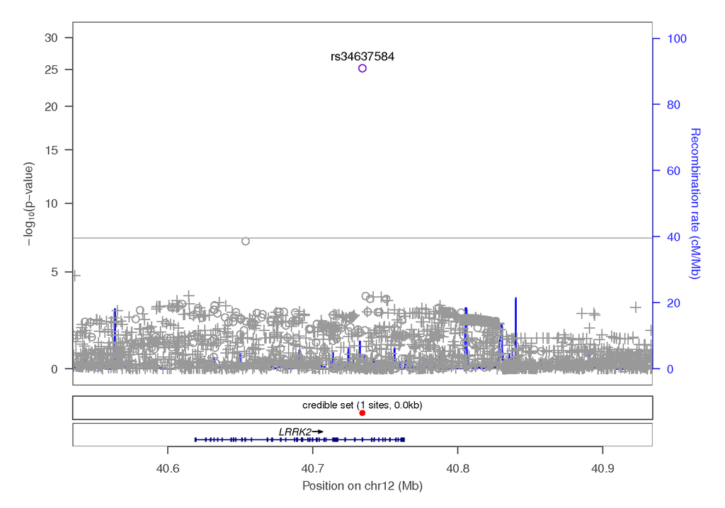

### rs356182 GPRIN3---[]--SNCA

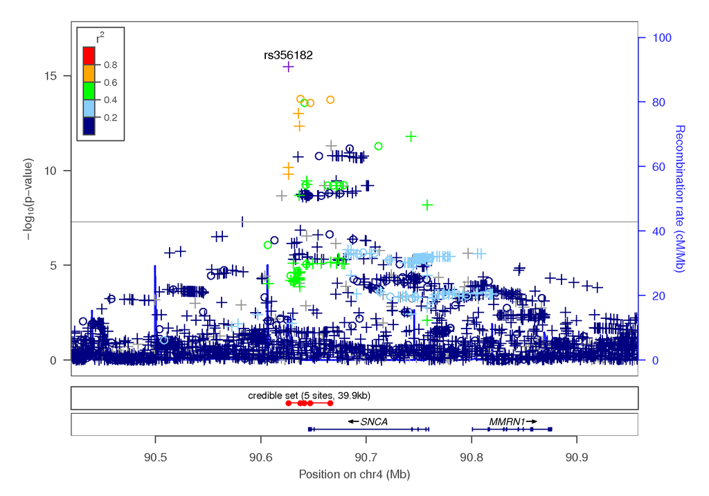

### rs200326647 [MAPT]

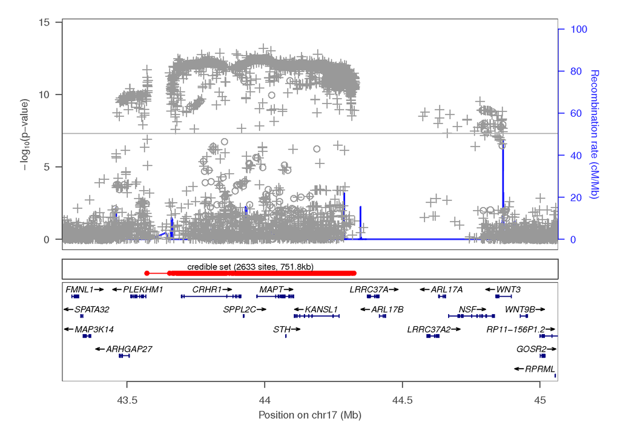

### rs10847839 [HIP1R]

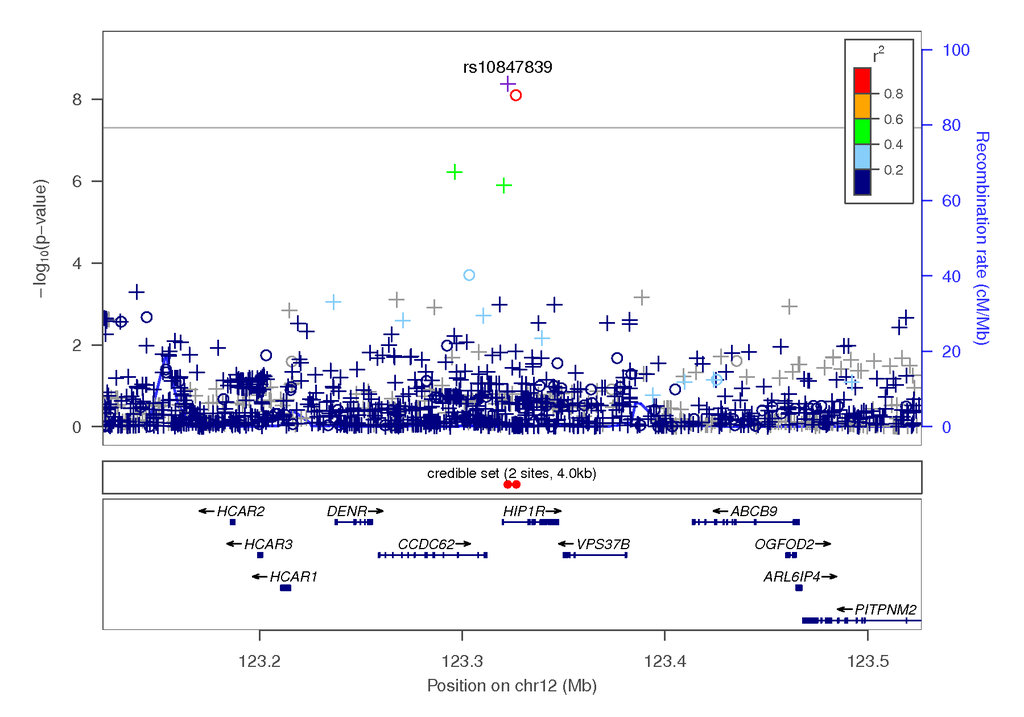

### rs57230454 [QRICH1]

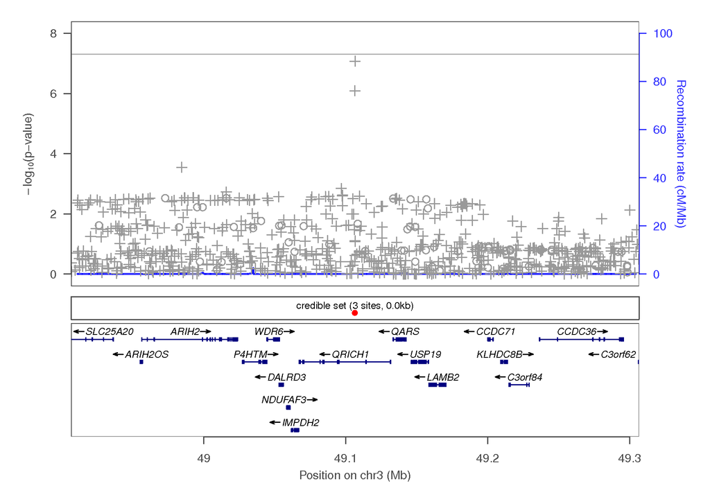

### rs56197340 [KIF26B]

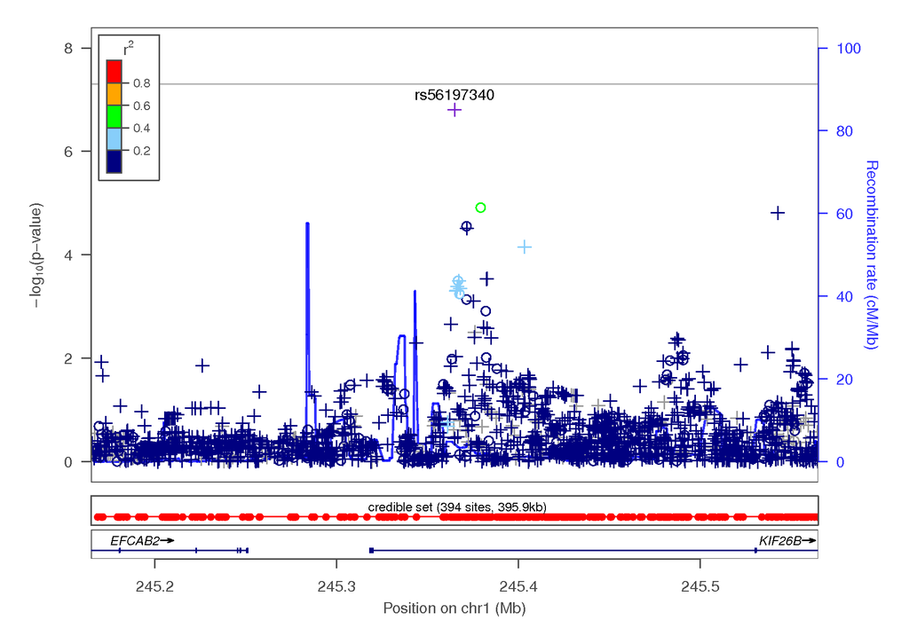

### rs73038484 TSPAN9--[]---PRMT8

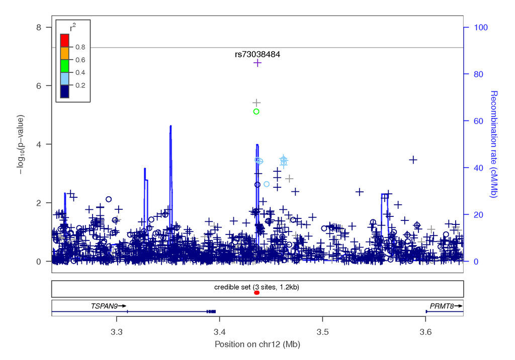

### rs71628639 [ZBTB7B]

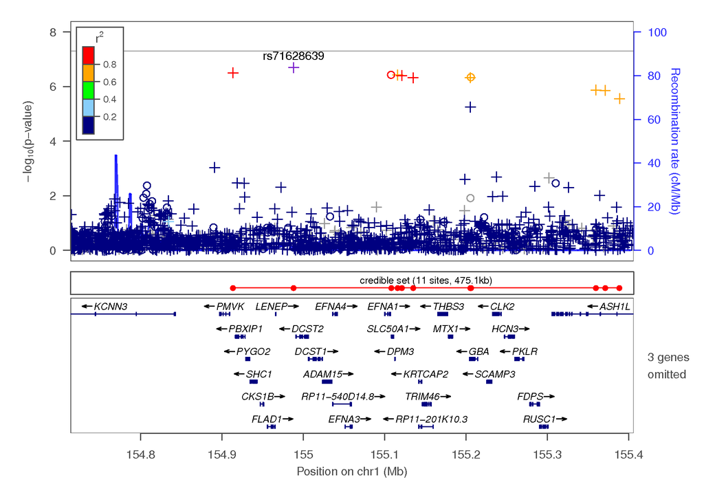

### rs34311866 [TMEM175]

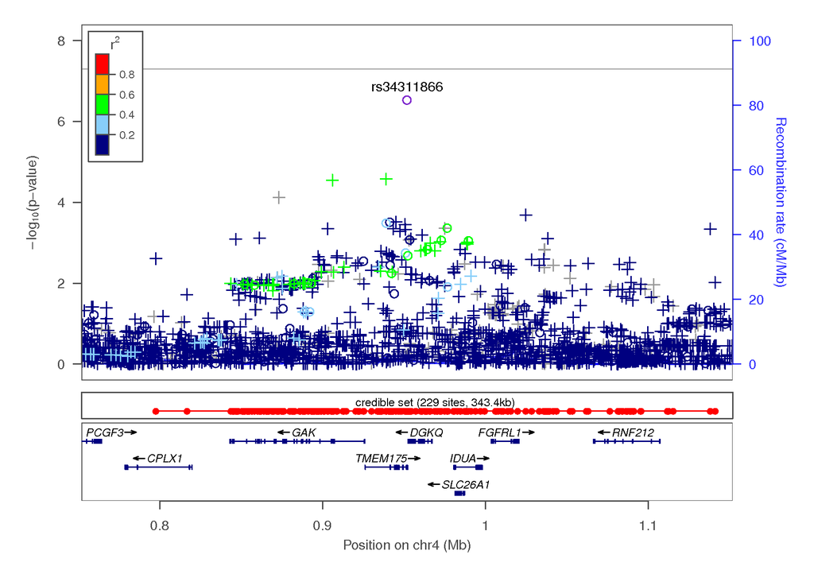

### rs141704337 DPT---[]--ATP1B1

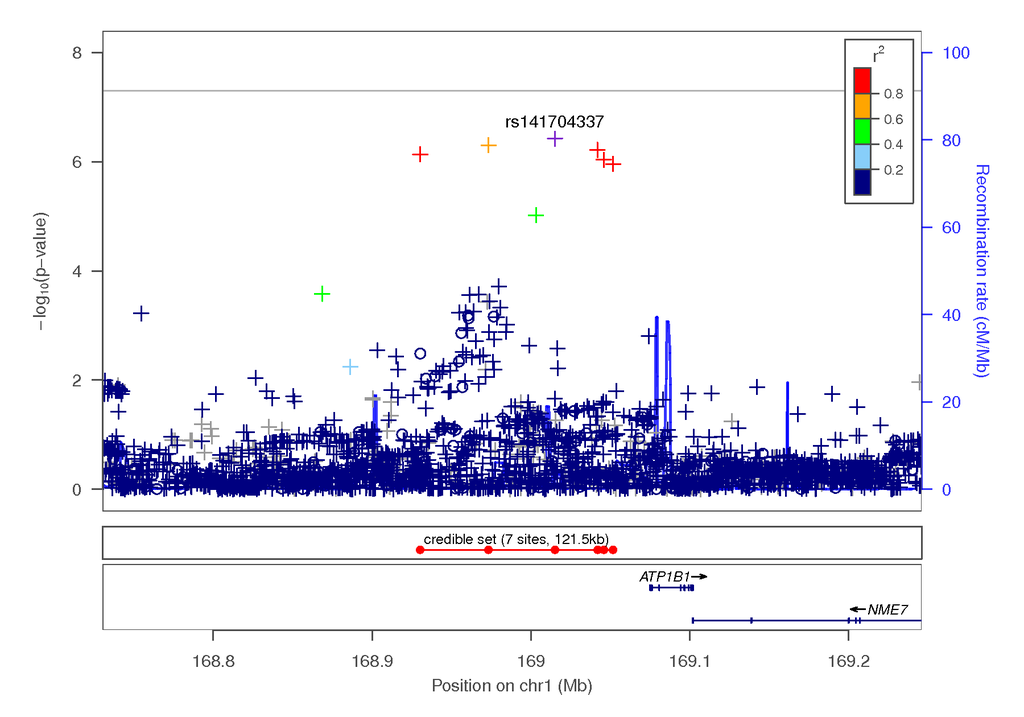

### rs2023472 [TRIM31]

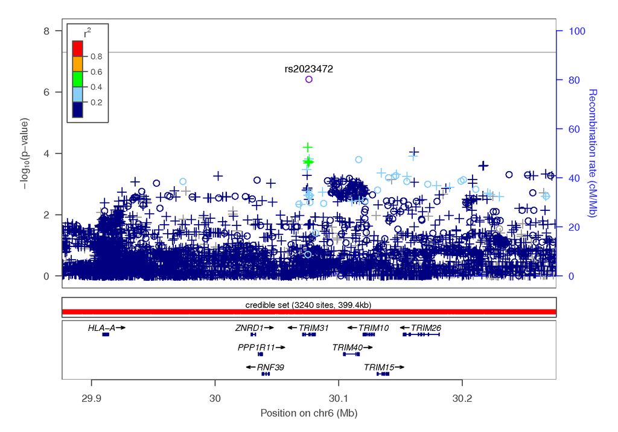

### rs77597318 SPOCK3---[]---ANXA10

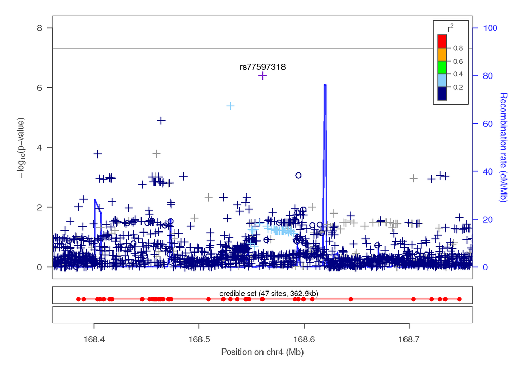

### rs139249720 [EPC1]

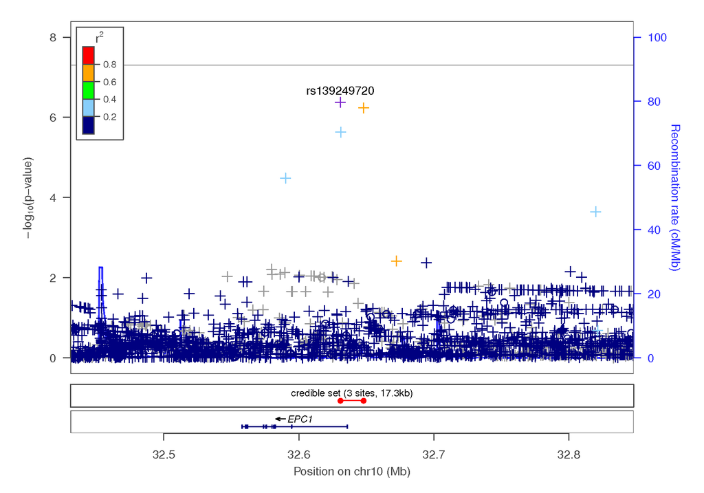

### rs181941027 FREM3--[]--GYPE

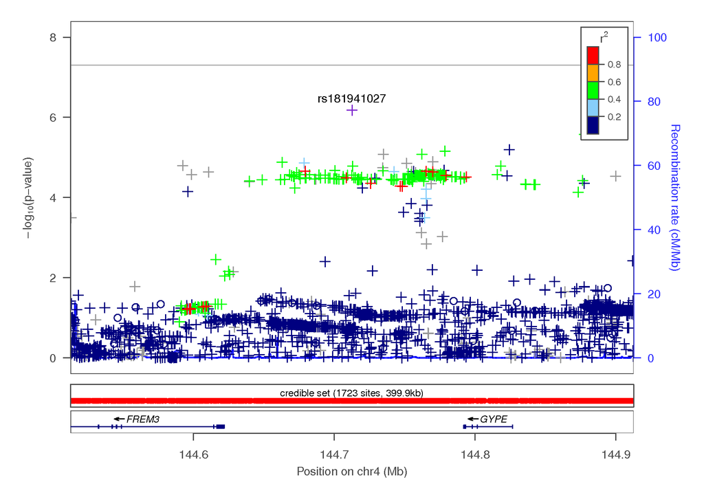

### rs187043470 [PDZRN4]

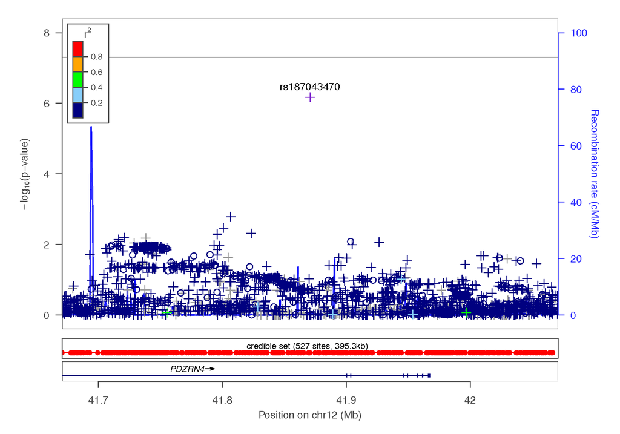

23andMe, Inc. — Proprietary/Confidential Information — Last updated 2018-01-26 20:22:24 PST